# Finance Data Project

# Exploratory Data Analysis

Let's explore the data a bit.

We'll figure out the max close price for each bank's stock throughout the time period

```python
bank_stocks.xs(key='Close', axis=1, level=1).max()
```

```
Bank Ticker
BAC     54.900002
C      564.100000
GS     247.919998
JPM     70.080002
MS      89.300003
WF      58.520000
dtype: float64
```

Let's create a new empty DataFrame called returns. This dataframe will contain the returns for each bank's stock. returns are typically defined by:

$$r_t = \frac{p_t - p_{t-1}}{p_{t-1}} = \frac{p_t}{p_{t-1}} - 1$$

```python
returns = pd.DataFrame()
```

We can use pandas pct_change() method on the Close column to create a column representing this return value, then create a for loop that goes and for each Bank Stock Ticker creates this returns column and set's it as a column in the returns DataFrame.

```python
for i in tickers:
    returns[i + ' Returns'] = bank_stocks[i]['Close'].pct_change()
returns.head()
```

| Date | BAC Returns | C Returns | GS Returns | JPM Returns | MS Returns | WF Returns |
| --- | --- | --- | --- | --- | --- | --- |
| 2006-01-03 | NaN | NaN | NaN | NaN | NaN | NaN |
| 2006-01-04 | -0.010620 | -0.018462 | -0.013812 | -0.014183 | 0.000686 | -0.011599 |
| 2006-01-05 | 0.001288 | 0.004961 | -0.000393 | 0.003029 | 0.002742 | -0.001110 |
| 2006-01-06 | -0.001501 | 0.000000 | 0.014169 | 0.007046 | 0.001025 | 0.005874 |
| 2006-01-09 | 0.000644 | -0.004731 | 0.012030 | 0.016242 | 0.010586 | -0.000158 |

Creating a pairplot using seaborn of the returns dataframe.

As we can see there is one stock that stands out.

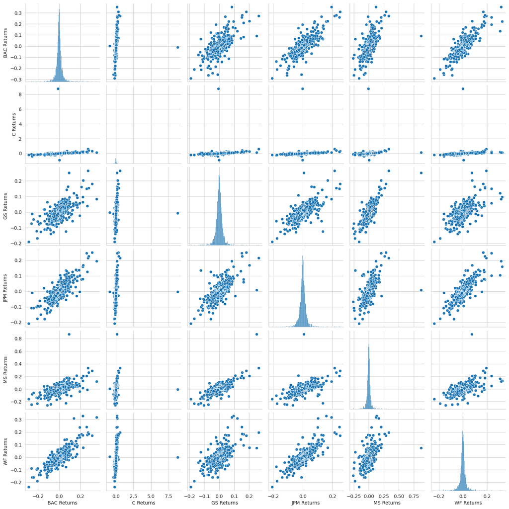

```python
sns.pairplot(returns)
```

Using this returns DataFrame, let's figure out on what dates each bank stock had the best and worst single day returns.

Noticeably, 4 of the banks share the same day for the worst drop. January 20th, 2009, or Inauguration day.

```python
returns.idxmin()
```

```
BAC Returns   2009-01-20
C Returns     2011-05-06
GS Returns    2009-01-20
JPM Returns   2009-01-20
MS Returns    2008-10-09
WF Returns    2009-01-20
dtype: datetime64[ns]
```

```python
returns.idxmax()
```

```
BAC Returns   2009-04-09
C Returns     2011-05-09
GS Returns    2008-11-24
JPM Returns   2009-01-21
MS Returns    2008-10-13
WF Returns    2008-07-16
dtype: datetime64[ns]
```

We also notice that Citigroup's largest drop and biggest gain were close to eachother. This was because Citigroup had a stock split

When we take a look at the standard deviation of the returns, Citigroup seems to be the riskiest

```python
returns.std()
```

```
BAC Returns    0.036647
C Returns      0.179969
GS Returns     0.025390
JPM Returns    0.027667
MS Returns     0.037819
WF Returns     0.030238
dtype: float64
```

```python
returns.loc['2015-01-01':'2015-12-31'].std()
```

```
BAC Returns    0.016163
C Returns      0.015289
GS Returns     0.014046
JPM Returns    0.014017
MS Returns     0.016249
WF Returns     0.012591
dtype: float64
```

Let's create a distplot using seaborn of the 2015 returns for Morgan Stanley

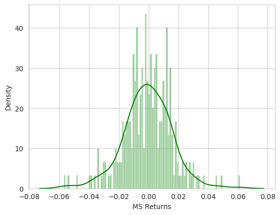

```python
sns.distplot(returns.loc['2015-01-01':'2015-12-31']['MS Returns'], bins=100, color='green')
```

Let's create a distplot using seaborn of the 2008 returns for CitiGroup

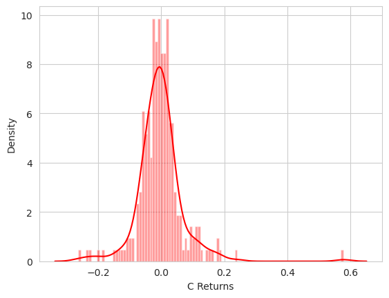

```python
sns.distplot(returns.loc['2008-01-01':'2008-12-31']['C Returns'], bins=100, color='red')
```

# More Visualization

Let's create a line plot showing Close price for each bank for the entire index of time.

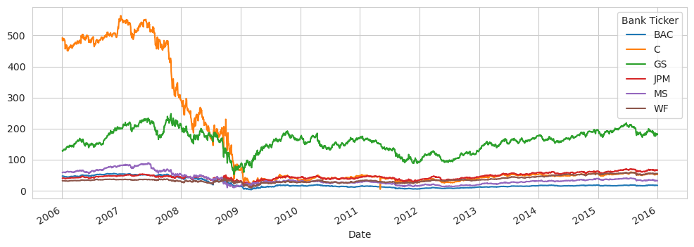

```python
bank_stocks.xs(key='Close', axis=1, level=1).plot(figsize=(12,4))
```

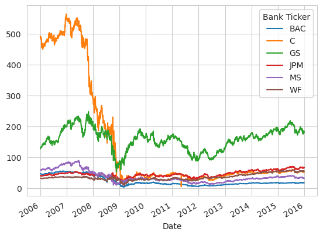

```python
bank_stocks.xs('Close', 1, 1).plot()
```

## Moving Averages

Let's analyze the moving averages for these stocks in the year 2008 and plot the rolling 30 day average against the Close Price for Bank Of America's stock for the year 2008

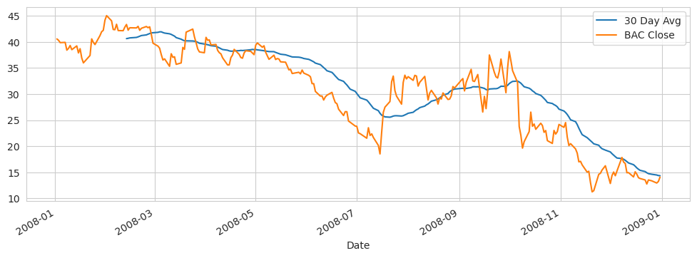

```python
plt.figure(figsize=(12,4))
BAC['Close'].loc['2008-01-01':'2009-01-01'].rolling(window=30).mean().plot(label='30 Day Avg')
BAC['Close'].loc['2008-01-01':'2009-01-01'].plot(label='BAC Close')
plt.legend()
```

Now let's create a heatmap of the correlation between the stocks Close Price.

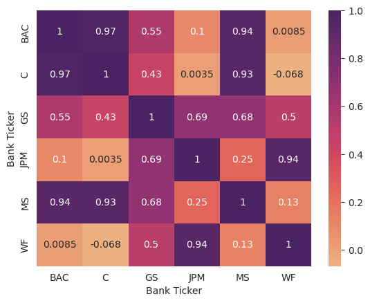

```python
sns.heatmap(bank_stocks.xs('Close', 1, 1).corr(), annot=True, cmap='flare')
```

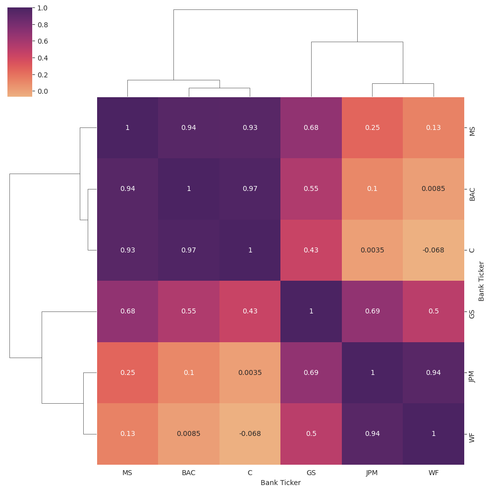

```python
sns.clustermap(bank_stocks.xs('Close', 1, 1).corr(), annot=True, cmap='flare')
```

Let's create a candle plot of Bank of America's stock from Jan 1st 2015 to Jan 1st 2016.

```python
BAC.loc['2015-01-01':'2016-01-01'].iplot(kind='candle')
```

[interactive chart not shown]

And now a Simple Moving Averages plot of Morgan Stanley for the year 2015.

```python
MS.loc['2015-01-01':'2015-12-31']['Close'].ta_plot(study='sma', periods=[13,21,55], title='Simple Moving Averages')
```

[interactive chart not shown]

Finally, let's create a Bollinger Band Plot for Bank of America for the year 2015.

```python
BAC.loc['2015-01-01':'2015-12-31']['Close'].ta_plot(study='boll')
```

[interactive chart not shown]